# 3.1 Разбиение выборки

Для начало я импортирую библеотеки которые буду использовать в работе

```python
import pandas as pd
from sklearn.model_selection import train_test_split
from sklearn.cluster import KMeans
import matplotlib.pyplot as plt
import seaborn as sns
from sklearn.decomposition import PCA
from sklearn.preprocessing import MinMaxScaler
from sklearn.cluster import BisectingKMeans
import numpy as np
import re
%matplotlib inline
```

Дальше мы читаем данные

```python
datesets = pd.read_csv('pain3.csv')
dataset_json = pd.read_json('Target.json')
```

Дальше мы Target.json разбиваем на колонку Nominations чтоб работать с ним

```python
Nominations = dataset_json['Target'].apply(lambda x: x['Nominations'])
```

так же мы его переменовали в Nominations для работы с ним

```python
Nominations = pd.DataFrame(np.repeat(Nominations,5))
```

```python
Nominations = Nominations.rename(columns={'Target' : 'Nominations'})
```

```python
dataset_json = pd.concat([ Nominations], axis=1)
```

```python
dataset_json
```

|  | Nominations |
| --- | --- |
| 0 | Здоровье и медицина |
| 0 | Здоровье и медицина |
| 0 | Здоровье и медицина |
| 0 | Здоровье и медицина |
| 0 | Здоровье и медицина |
| ... | ... |
| 21 | Образование и Кадры |
| 21 | Образование и Кадры |
| 21 | Образование и Кадры |
| 21 | Образование и Кадры |
| 21 | Образование и Кадры |

110 rows × 1 columns

Ну а дпльше мы уже готовый результат добавляем в основной датасет (datesets)

```python
datesets = dataset_json.join(datesets)
```

```python
datesets
```

|  | Nominations | абсолютно | автоматизация | автоматизированный | автоматизировать | автоматически | автоматический | автор | адрес | активно | ... | эффект | эффективно | эффективность | эффективный | являться | явно | ядро | язык | язык программирование | яндекс |
| --- | --- | --- | --- | --- | --- | --- | --- | --- | --- | --- | --- | --- | --- | --- | --- | --- | --- | --- | --- | --- | --- |
| 0 | Здоровье и медицина | 0.045896 | 0.000000 | 0.000000 | 0.0 | 0.000000 | 0.000000 | 0.0 | 0.0 | 0.037486 | ... | 0.04004 | 0.0 | 0.000000 | 0.0 | 0.052057 | 0.0 | 0.0 | 0.072743 | 0.0 | 0.0 |
| 0 | Здоровье и медицина | 0.045896 | 0.000000 | 0.000000 | 0.0 | 0.000000 | 0.000000 | 0.0 | 0.0 | 0.037486 | ... | 0.04004 | 0.0 | 0.000000 | 0.0 | 0.052057 | 0.0 | 0.0 | 0.072743 | 0.0 | 0.0 |
| 0 | Здоровье и медицина | 0.045896 | 0.000000 | 0.000000 | 0.0 | 0.000000 | 0.000000 | 0.0 | 0.0 | 0.037486 | ... | 0.04004 | 0.0 | 0.000000 | 0.0 | 0.052057 | 0.0 | 0.0 | 0.072743 | 0.0 | 0.0 |
| 0 | Здоровье и медицина | 0.045896 | 0.000000 | 0.000000 | 0.0 | 0.000000 | 0.000000 | 0.0 | 0.0 | 0.037486 | ... | 0.04004 | 0.0 | 0.000000 | 0.0 | 0.052057 | 0.0 | 0.0 | 0.072743 | 0.0 | 0.0 |
| 0 | Здоровье и медицина | 0.045896 | 0.000000 | 0.000000 | 0.0 | 0.000000 | 0.000000 | 0.0 | 0.0 | 0.037486 | ... | 0.04004 | 0.0 | 0.000000 | 0.0 | 0.052057 | 0.0 | 0.0 | 0.072743 | 0.0 | 0.0 |
| ... | ... | ... | ... | ... | ... | ... | ... | ... | ... | ... | ... | ... | ... | ... | ... | ... | ... | ... | ... | ... | ... |
| 21 | Образование и Кадры | 0.010194 | 0.009391 | 0.009975 | 0.0 | 0.032296 | 0.018434 | 0.0 | 0.0 | 0.024977 | ... | 0.00000 | 0.0 | 0.027153 | 0.0 | 0.034687 | 0.0 | 0.0 | 0.012925 | 0.0 | 0.0 |
| 21 | Образование и Кадры | 0.010194 | 0.009391 | 0.009975 | 0.0 | 0.032296 | 0.018434 | 0.0 | 0.0 | 0.024977 | ... | 0.00000 | 0.0 | 0.027153 | 0.0 | 0.034687 | 0.0 | 0.0 | 0.012925 | 0.0 | 0.0 |
| 21 | Образование и Кадры | 0.010194 | 0.009391 | 0.009975 | 0.0 | 0.032296 | 0.018434 | 0.0 | 0.0 | 0.024977 | ... | 0.00000 | 0.0 | 0.027153 | 0.0 | 0.034687 | 0.0 | 0.0 | 0.012925 | 0.0 | 0.0 |
| 21 | Образование и Кадры | 0.010194 | 0.009391 | 0.009975 | 0.0 | 0.032296 | 0.018434 | 0.0 | 0.0 | 0.024977 | ... | 0.00000 | 0.0 | 0.027153 | 0.0 | 0.034687 | 0.0 | 0.0 | 0.012925 | 0.0 | 0.0 |
| 21 | Образование и Кадры | 0.010194 | 0.009391 | 0.009975 | 0.0 | 0.032296 | 0.018434 | 0.0 | 0.0 | 0.024977 | ... | 0.00000 | 0.0 | 0.027153 | 0.0 | 0.034687 | 0.0 | 0.0 | 0.012925 | 0.0 | 0.0 |

110 rows × 1503 columns

##### Для обучения модели я буду использовать:

MultinomialNB - Многочленный классификатор наивного Байеса подходит для классификации с дискретными признаками (например, количеством слов для классификации текста). Для мультиномиального распределения обычно требуется целочисленное количество объектов. Однако на практике могут также работать дробные подсчеты, такие как tf-idf.

ComplementNB - Дополняющий наивный байесовский классификатор был разработан для исправления “серьезных допущений”, сделанных стандартным многочленным наивным байесовским классификатором. Она особенно подходит для несбалансированных наборов данных.

RandomForestClassifier - это метаоценщик, который соответствует ряду классификаторов дерева решений в различных подвыборках набора данных и использует усреднение для повышения точности прогнозирования и контроля над подгонкой.

я взял именно их так как они хорошо будут работать с нашим датасетом

Импортируем эти модели

```python
from sklearn.naive_bayes import MultinomialNB
from sklearn.naive_bayes import ComplementNB
from sklearn.ensemble import RandomForestClassifier
```

#### Так же для метрики я буду использовать:

```
f1_score - Оценка F1 может быть интерпретирована как среднее гармоническое точности и отзыва, где оценка F1 достигает своего наилучшего значения при 1 и худшего значения при 0.
accuracy_score - При классификации с несколькими метками эта функция вычисляет точность подмножества: набор меток, предсказанный для выборки, должен точно соответствовать соответствующему набору меток в y_true.
```

```python
from sklearn.metrics import f1_score, accuracy_score
```

MultinomialNB

### обучения модели

Для начало мы их разделим на тестувую и обучающию:  
Набор для обучения: используется для обучения модели.  
Тестовый набор: используется для получения объективной оценки производительности модели.

```python
x = datesets.drop('Nominations', axis=1)
y = datesets['Nominations']


X_train, X_test, y_train, y_test = train_test_split(x, y, test_size=0.3, random_state=0, stratify=datesets['Nominations'])
```

```python
print(X_train.shape, X_test.shape)
```

```
(77, 1502) (33, 1502)
```

### MultinomialNB

```python
MNB  = MultinomialNB().fit(X_train, y_train)
```

```python
f1_score(MNB.predict(X_test), y_test, average='weighted')
```

```
1.0
```

```python
accuracy_score(MNB.predict(X_test), y_test,)
```

```
1.0
```

### RandomForestClassifier

```python
RFC = RandomForestClassifier().fit(X_train, y_train)
```

```python
f1_score(RFC.predict(X_test), y_test, average='weighted')
```

```
1.0
```

```python
accuracy_score(RFC.predict(X_test), y_test,)
```

```
1.0
```

### ComplementNB

```python
CNB = ComplementNB().fit(X_train, y_train)
```

```python
f1_score(CNB.predict(X_test), y_test, average='weighted')
```

```
1.0
```

```python
accuracy_score(CNB.predict(X_test), y_test)
```

```
1.0
```

# 3.2 Оптимизация модели

```python
from sklearn.datasets import load_iris
from sklearn.feature_selection import SelectKBest, chi2
```

```python
datesets_drop = datesets.drop(columns='Nominations').sum().sort_values()
```

```python
x, y = load_iris(return_X_y=True)
```

```python
from sklearn.feature_selection import chi2
from sklearn.feature_selection import SelectKBest
select = SelectKBest(chi2, k=50)
X_new = select.fit_transform(X_train, y_train)
```

```python
select.get_feature_names_out()
```

```
array(['база данные', 'библиотека', 'бизнес', 'биржа',
       'большой количество', 'ваш', 'видео', 'дизайн', 'дизайнер',
       'задача', 'запись', 'запрос', 'защита', 'инструмент', 'интересно',
       'клиентский', 'книга', 'коллега', 'команда', 'компания', 'мало',
       'настройка', 'описание', 'передача', 'планирование', 'поток',
       'приложение', 'проверка', 'протокол', 'процесс', 'репозиторий',
       'рынок', 'свойство', 'смотреть', 'текст', 'тест', 'тестировщик',
       'тестовый', 'товар', 'торговый', 'управление', 'устройство',
       'фактор', 'чат', 'читать', 'чтение', 'экономить', 'экран',
       'это сделать', 'язык'], dtype=object)
```

```python
import pickle
```

```python
with open("kbest.pkl", "wb") as write_to:
    pickle.dump(select, write_to)
```

```python
with open("kbest.pkl", "rb") as read_from:
    test = pickle.load(read_from)
```

```python
test.get_feature_names_out()
```

```
array(['база данные', 'библиотека', 'бизнес', 'биржа',
       'большой количество', 'ваш', 'видео', 'дизайн', 'дизайнер',
       'задача', 'запись', 'запрос', 'защита', 'инструмент', 'интересно',
       'клиентский', 'книга', 'коллега', 'команда', 'компания', 'мало',
       'настройка', 'описание', 'передача', 'планирование', 'поток',
       'приложение', 'проверка', 'протокол', 'процесс', 'репозиторий',
       'рынок', 'свойство', 'смотреть', 'текст', 'тест', 'тестировщик',
       'тестовый', 'товар', 'торговый', 'управление', 'устройство',
       'фактор', 'чат', 'читать', 'чтение', 'экономить', 'экран',
       'это сделать', 'язык'], dtype=object)
```

```python
from sklearn.decomposition import PCA
```

```python
pca = PCA().fit(X_new)
```

```python
test = pca.fit_transform(X_new)
```

```python
test
```

```
array([[-2.45726442e-02,  4.26670345e-02, -1.39702761e-01, ...,
        -5.98091288e-33,  1.11900740e-32, -1.92502901e-17],
       [-5.45905633e-03,  3.15360603e-02,  6.49625178e-02, ...,
         8.32554662e-33,  5.02751994e-33,  9.77501275e-18],
       [-2.04784248e-02,  2.20338366e-02, -1.10744819e-02, ...,
        -5.69456784e-33, -7.86250043e-33,  2.58990020e-18],
       ...,
       [-1.76228525e-01, -8.69228879e-02, -1.46105181e-01, ...,
         1.03341476e-32,  3.24461976e-32,  1.01900659e-18],
       [ 8.24285506e-02,  1.24371217e-01,  1.39434383e-01, ...,
         7.83238555e-32, -6.49852750e-32,  3.73799605e-19],
       [-5.45905633e-03,  3.15360603e-02,  6.49625178e-02, ...,
         3.54530775e-33, -3.81484878e-33, -4.32680697e-18]])
```

```python
from sklearn import svm
from sklearn.model_selection import GridSearchCV
```

```python
parameters = {'n_estimators':[60, 80, 100], 'max_depth':[None, 1 , 10]}
```

```python
RFC = RandomForestClassifier()
```

```python
GSC = GridSearchCV(RFC, parameters).fit(X_train, y_train)
```

```python
datesets_GSC = pd.DataFrame(GSC.cv_results_)
```

```python
datesets_GSC
```

|  | mean_fit_time | std_fit_time | mean_score_time | std_score_time | param_max_depth | param_n_estimators | params | split0_test_score | split1_test_score | split2_test_score | split3_test_score | split4_test_score | mean_test_score | std_test_score | rank_test_score |
| --- | --- | --- | --- | --- | --- | --- | --- | --- | --- | --- | --- | --- | --- | --- | --- |
| 0 | 0.079013 | 0.004525 | 0.012586 | 0.000469 | None | 60 | {'max_depth': None, 'n_estimators': 60} | 1.0000 | 0.8750 | 1.000000 | 1.0 | 1.000000 | 0.975000 | 0.050000 | 3 |
| 1 | 0.100193 | 0.001708 | 0.014008 | 0.000645 | None | 80 | {'max_depth': None, 'n_estimators': 80} | 1.0000 | 0.8750 | 1.000000 | 1.0 | 1.000000 | 0.975000 | 0.050000 | 3 |
| 2 | 0.125399 | 0.003555 | 0.015201 | 0.000400 | None | 100 | {'max_depth': None, 'n_estimators': 100} | 1.0000 | 0.8750 | 1.000000 | 1.0 | 1.000000 | 0.975000 | 0.050000 | 3 |
| 3 | 0.066600 | 0.000489 | 0.011999 | 0.000001 | 1 | 60 | {'max_depth': 1, 'n_estimators': 60} | 1.0000 | 0.7500 | 0.600000 | 0.8 | 0.866667 | 0.803333 | 0.131825 | 9 |
| 4 | 0.086806 | 0.000741 | 0.013200 | 0.000400 | 1 | 80 | {'max_depth': 1, 'n_estimators': 80} | 0.9375 | 0.8125 | 0.800000 | 1.0 | 1.000000 | 0.910000 | 0.087821 | 7 |
| 5 | 0.105804 | 0.000748 | 0.014400 | 0.000492 | 1 | 100 | {'max_depth': 1, 'n_estimators': 100} | 0.9375 | 0.7500 | 0.733333 | 1.0 | 0.733333 | 0.830833 | 0.114492 | 8 |
| 6 | 0.073398 | 0.000491 | 0.012000 | 0.000003 | 10 | 60 | {'max_depth': 10, 'n_estimators': 60} | 1.0000 | 1.0000 | 1.000000 | 1.0 | 1.000000 | 1.000000 | 0.000000 | 1 |
| 7 | 0.095996 | 0.001109 | 0.013405 | 0.000486 | 10 | 80 | {'max_depth': 10, 'n_estimators': 80} | 1.0000 | 1.0000 | 1.000000 | 1.0 | 1.000000 | 1.000000 | 0.000000 | 1 |
| 8 | 0.120400 | 0.002059 | 0.014994 | 0.000014 | 10 | 100 | {'max_depth': 10, 'n_estimators': 100} | 1.0000 | 0.8750 | 1.000000 | 1.0 | 1.000000 | 0.975000 | 0.050000 | 3 |

```python
from sklearn.model_selection import validation_curve
from sklearn.datasets import load_iris
from sklearn.linear_model import Ridge
```

```python
x_plot = datesets_GSC['params']
y_plot = datesets_GSC['mean_test_score']
```

```python
test = [f"{x['max_depth']}-{x['n_estimators']}" for x in x_plot]
```

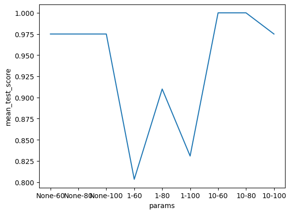

```python
plt.plot(test, y_plot)
plt.xlabel('params')
plt.ylabel('mean_test_score')
plt.show()
```

```python
pip install --upgrade scikit-learn
```